# Syntax

```r
library(ggplot2)
library(fivethirtyeight)
```

## Syntax in ggplot2

There are many ways to “say” the same thing in ggplot2

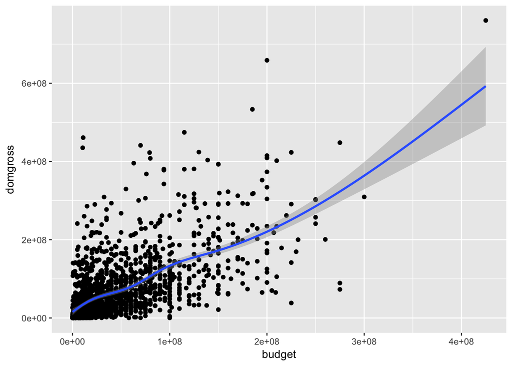

```r
ggplot(data = bechdel) +
  geom_point(mapping = aes(x = budget, y = domgross)) +
  geom_smooth(mapping = aes(x= budget, y = domgross))
```

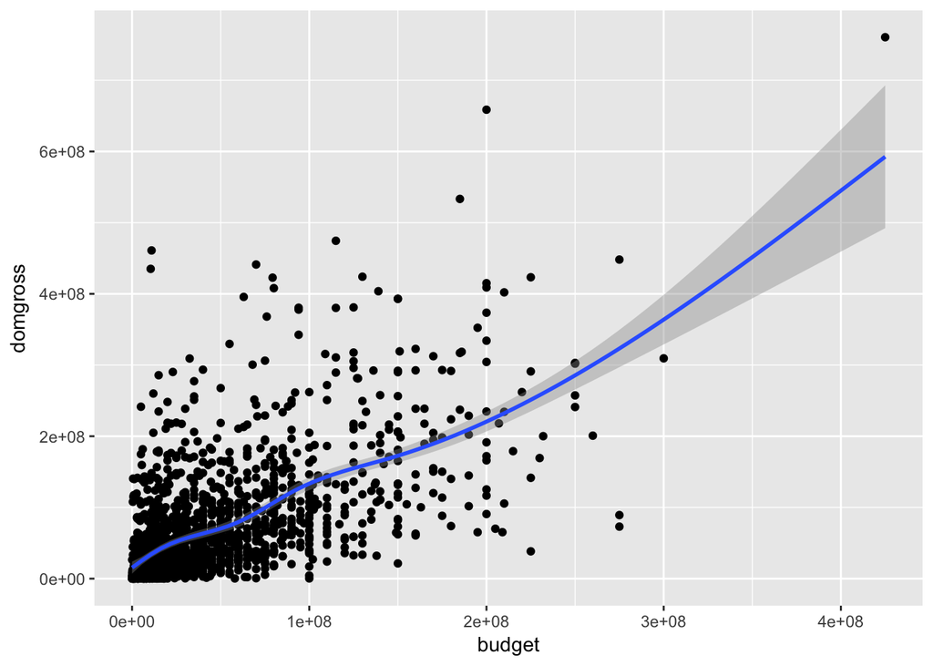

```r
ggplot(data = bechdel, aes(x= budget, y = domgross)) +
  geom_point() +
  geom_smooth()
```

```r
ggplot(bechdel) +
  geom_point(aes(x = budget, y = domgross))
ggplot(bechdel, aes(x = budget, y = domgross)) +
  geom_point()
ggplot(bechdel, aes(x= budget)) +
  geom_point(aes(y = domgross))
```

[output not shown]

Override the global mappings

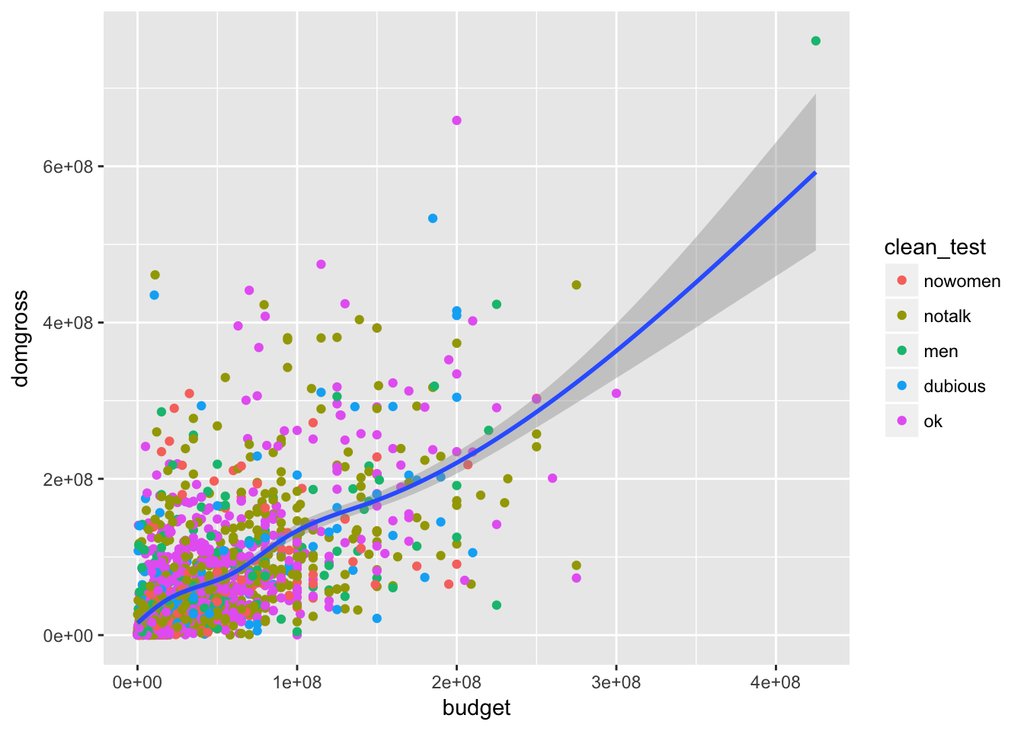

```r
ggplot(data = bechdel, aes(x= budget, y = domgross)) +
  geom_point(aes(color=clean_test)) +
  geom_smooth()
```

## Subsetting

## The dplyr way

To use the dplyr package, we need to load it.

```r
library(dplyr)
```

## Beatles data

Let’s make a toy dataset to play with.

```r
beatles <- data.frame(
  name = c("John", "Paul", "George", "Ringo"),
  birth = c(1940, 1942, 1943, 1940),
  instrument = c("guitar", "bass", "guitar", "drums")
)
```

## Select

Select is a way to extract columns from dataframes

```r
select(beatles, name, birth)
```

| name | birth |
| --- | --- |
| John | 1940 |
| Paul | 1942 |
| George | 1943 |
| Ringo | 1940 |

## Your turn

Select just the instrument column

## Base R

```r
beatles[2,3]
```

```
## [1] bass
## Levels: bass drums guitar
```

```r
beatles[ ,"birth"]
```

```
## [1] 1940 1942 1943 1940
```

```r
beatles[ ,c("name","birth")]
```

| name | birth |
| --- | --- |
| John | 1940 |
| Paul | 1942 |
| George | 1943 |
| Ringo | 1940 |

```r
beatles$birth
```

```
## [1] 1940 1942 1943 1940
```

## Your turn

Select just the instrument column using brackets

Select just the instrument column using a dollar sign.

## Filter

```r
filter(beatles, name == "George")
```

| name | birth | instrument |
| --- | --- | --- |
| George | 1943 | guitar |

## Your turn

## More than one condition

```r
filter(beatles, birth==1940, instrument == "guitar")
```

| name | birth | instrument |
| --- | --- | --- |
| John | 1940 | guitar |

```r
filter(beatles, birth==1940 & instrument == "guitar")
```

| name | birth | instrument |
| --- | --- | --- |
| John | 1940 | guitar |

## Your turn

Modify the code below to filter out the rows for which birth is 1943 or instrument is drums

```r
filter(beatles, birth==1940 & instrument == "guitar")
```

| name | birth | instrument |
| --- | --- | --- |
| John | 1940 | guitar |

## Base R

```r
beatles[c(FALSE,TRUE,TRUE,FALSE), ]
```

|  | name | birth | instrument |
| --- | --- | --- | --- |
| 2 | Paul | 1942 | bass |
| 3 | George | 1943 | guitar |

```r
beatles[beatles$birth == 1940, ]
```

|  | name | birth | instrument |
| --- | --- | --- | --- |
| 1 | John | 1940 | guitar |
| 4 | Ringo | 1940 | drums |

## Your turn

## Baby names data

Names with at least 5 uses in a particular year, from the Social Security Administration.

```r
library(babynames)
```

## Your turn

Do you remember how to view a dataset?

## Saving results

```r
filter(babynames, name %in% c("Acura", "Lexus", "Yugo"))
```

| year | sex | name | n | prop |
| --- | --- | --- | --- | --- |
| 1990 | F | Lexus | 36 | 1.752932e-05 |
| 1990 | M | Lexus | 12 | 5.579156e-06 |
| 1991 | F | Lexus | 102 | 5.017270e-05 |
| 1991 | M | Lexus | 16 | 7.550774e-06 |
| 1992 | F | Lexus | 193 | 9.629941e-05 |
| 1992 | M | Lexus | 25 | 1.191371e-05 |
| 1993 | F | Lexus | 285 | 1.445945e-04 |
| 1993 | M | Lexus | 30 | 1.452921e-05 |
| 1994 | F | Lexus | 381 | 1.954974e-04 |
| 1994 | F | Acura | 6 | 3.078699e-06 |

[output cut: 45 more lines]

```r
carnames <- filter(babynames, name %in% c("Acura", "Lexus", "Yugo"))
```

```r
babynames <- filter(babynames, name %in% c("Acura", "Lexus", "Yugo")) # dangerous!
rm(babynames)
str(babynames) #phew!
```

```
## Classes 'tbl_df', 'tbl' and 'data.frame':    1858689 obs. of  5 variables:
##  $ year: num  1880 1880 1880 1880 1880 1880 1880 1880 1880 1880 ...
##  $ sex : chr  "F" "F" "F" "F" ...
##  $ name: chr  "Mary" "Anna" "Emma" "Elizabeth" ...
##  $ n   : int  7065 2604 2003 1939 1746 1578 1472 1414 1320 1288 ...
##  $ prop: num  0.0724 0.0267 0.0205 0.0199 0.0179 ...
```

## Your turn

Try to: - Filter out the babynames data for your name. (You may want to also filter for your gender) - Assign that data its own name - Use your subsetted data to create a ggplot graphic of the popularity of your name over time

## Steps

```r
boys_2015 <- filter(babynames, year == 2015, sex == "M")
boys_2015 <- select(boys_2015, name, n)
boys_2015 <- arrange(boys_2015, desc(n))
boys_2015
```

| name | n |
| --- | --- |
| Noah | 19511 |
| Liam | 18281 |
| Mason | 16535 |
| Jacob | 15816 |
| William | 15809 |
| Ethan | 14991 |
| James | 14705 |
| Alexander | 14460 |
| Michael | 14321 |
| Benjamin | 13608 |

[output cut: 9990 more lines]

Nested nonsense

```r
arrange(select(filter(babynames, year == 2015,
  sex == "M"), name, n), desc(n))
```

| name | n |
| --- | --- |
| Noah | 19511 |
| Liam | 18281 |
| Mason | 16535 |
| Jacob | 15816 |
| William | 15809 |
| Ethan | 14991 |
| James | 14705 |
| Alexander | 14460 |
| Michael | 14321 |
| Benjamin | 13608 |

[output cut: 9990 more lines]

## Piping

The `%>%` operator is the pipe. We can reorganized our code like so:

```r
babynames %>%
  filter(year == 2015, sex == "M") %>%
  select(name, n) %>%
  arrange(desc(n))
```

| name | n |
| --- | --- |
| Noah | 19511 |
| Liam | 18281 |
| Mason | 16535 |
| Jacob | 15816 |
| William | 15809 |
| Ethan | 14991 |
| James | 14705 |
| Alexander | 14460 |
| Michael | 14321 |
| Benjamin | 13608 |

[output cut: 9990 more lines]

[Tip: type Cmd Shift M to insert a pipe]

## Your turn

Use %>% to write a sequence of functions that: - Filter babynames to just the girls that were born in 2015 - Select the `name` and `n` columns - Arrange the results so that the most popular names are near the top.

## Diamonds data